# Risk Factor Analysis

## Outcome Variable

**Outcome Variable:** ever_stunted

## Predictor Variables

**Intervention Variable:** single

**Adjustment Set:**

- arm
- W_mage
- meducyrs
- feducyrs
- W_mhtcm
- W_mwtkg
- W_mbmi
- delta_W_mage
- delta_meducyrs
- delta_feducyrs
- delta_W_mhtcm
- delta_W_mwtkg
- delta_W_mbmi

## Stratifying Variables

The analysis was stratified on these variable(s):

- agecat
- studyid
- country

## Data Summary

| agecat | studyid | country | single | ever_stunted | n_cell | n |
| --- | --- | --- | --- | --- | --- | --- |
| 0-24 months | ki0047075b-MAL-ED | BANGLADESH | 0 | 0 | 104 | 265 |
| 0-24 months | ki0047075b-MAL-ED | BANGLADESH | 0 | 1 | 161 | 265 |
| 0-24 months | ki0047075b-MAL-ED | BANGLADESH | 1 | 0 | 0 | 265 |
| 0-24 months | ki0047075b-MAL-ED | BANGLADESH | 1 | 1 | 0 | 265 |
| 0-24 months | ki0047075b-MAL-ED | BRAZIL | 0 | 0 | 154 | 233 |
| 0-24 months | ki0047075b-MAL-ED | BRAZIL | 0 | 1 | 43 | 233 |
| 0-24 months | ki0047075b-MAL-ED | BRAZIL | 1 | 0 | 25 | 233 |
| 0-24 months | ki0047075b-MAL-ED | BRAZIL | 1 | 1 | 11 | 233 |
| 0-24 months | ki0047075b-MAL-ED | INDIA | 0 | 0 | 101 | 249 |
| 0-24 months | ki0047075b-MAL-ED | INDIA | 0 | 1 | 148 | 249 |
| 0-24 months | ki0047075b-MAL-ED | INDIA | 1 | 0 | 0 | 249 |
| 0-24 months | ki0047075b-MAL-ED | INDIA | 1 | 1 | 0 | 249 |
| 0-24 months | ki0047075b-MAL-ED | NEPAL | 0 | 0 | 157 | 240 |
| 0-24 months | ki0047075b-MAL-ED | NEPAL | 0 | 1 | 83 | 240 |
| 0-24 months | ki0047075b-MAL-ED | NEPAL | 1 | 0 | 0 | 240 |
| 0-24 months | ki0047075b-MAL-ED | NEPAL | 1 | 1 | 0 | 240 |
| 0-24 months | ki0047075b-MAL-ED | PERU | 0 | 0 | 101 | 303 |
| 0-24 months | ki0047075b-MAL-ED | PERU | 0 | 1 | 167 | 303 |
| 0-24 months | ki0047075b-MAL-ED | PERU | 1 | 0 | 14 | 303 |
| 0-24 months | ki0047075b-MAL-ED | PERU | 1 | 1 | 21 | 303 |
| 0-24 months | ki0047075b-MAL-ED | SOUTH AFRICA | 0 | 0 | 82 | 314 |
| 0-24 months | ki0047075b-MAL-ED | SOUTH AFRICA | 0 | 1 | 94 | 314 |
| 0-24 months | ki0047075b-MAL-ED | SOUTH AFRICA | 1 | 0 | 61 | 314 |
| 0-24 months | ki0047075b-MAL-ED | SOUTH AFRICA | 1 | 1 | 77 | 314 |
| 0-24 months | ki0047075b-MAL-ED | TANZANIA, UNITED REPUBLIC OF | 0 | 0 | 38 | 262 |
| 0-24 months | ki0047075b-MAL-ED | TANZANIA, UNITED REPUBLIC OF | 0 | 1 | 214 | 262 |
| 0-24 months | ki0047075b-MAL-ED | TANZANIA, UNITED REPUBLIC OF | 1 | 0 | 3 | 262 |
| 0-24 months | ki0047075b-MAL-ED | TANZANIA, UNITED REPUBLIC OF | 1 | 1 | 7 | 262 |
| 0-24 months | ki1066203-TanzaniaChild2 | TANZANIA, UNITED REPUBLIC OF | 0 | 0 | 1400 | 2375 |
| 0-24 months | ki1066203-TanzaniaChild2 | TANZANIA, UNITED REPUBLIC OF | 0 | 1 | 751 | 2375 |

[output cut: 138 more lines]

The following strata were considered:

- agecat: 0-24 months, studyid: ki0047075b-MAL-ED, country: BANGLADESH
- agecat: 0-24 months, studyid: ki0047075b-MAL-ED, country: BRAZIL
- agecat: 0-24 months, studyid: ki0047075b-MAL-ED, country: INDIA
- agecat: 0-24 months, studyid: ki0047075b-MAL-ED, country: NEPAL
- agecat: 0-24 months, studyid: ki0047075b-MAL-ED, country: PERU
- agecat: 0-24 months, studyid: ki0047075b-MAL-ED, country: SOUTH AFRICA
- agecat: 0-24 months, studyid: ki0047075b-MAL-ED, country: TANZANIA, UNITED REPUBLIC OF
- agecat: 0-24 months, studyid: ki1066203-TanzaniaChild2, country: TANZANIA, UNITED REPUBLIC OF
- agecat: 0-24 months, studyid: ki1112895-Guatemala BSC, country: GUATEMALA
- agecat: 0-24 months, studyid: ki1119695-PROBIT, country: BELARUS
- agecat: 0-24 months, studyid: ki1126311-ZVITAMBO, country: ZIMBABWE
- agecat: 0-24 months, studyid: ki1135781-COHORTS, country: GUATEMALA
- agecat: 0-24 months, studyid: ki1135781-COHORTS, country: INDIA
- agecat: 0-24 months, studyid: ki1135781-COHORTS, country: PHILIPPINES
- agecat: 0-6 months, studyid: ki0047075b-MAL-ED, country: BANGLADESH
- agecat: 0-6 months, studyid: ki0047075b-MAL-ED, country: BRAZIL
- agecat: 0-6 months, studyid: ki0047075b-MAL-ED, country: INDIA
- agecat: 0-6 months, studyid: ki0047075b-MAL-ED, country: NEPAL
- agecat: 0-6 months, studyid: ki0047075b-MAL-ED, country: PERU
- agecat: 0-6 months, studyid: ki0047075b-MAL-ED, country: SOUTH AFRICA
- agecat: 0-6 months, studyid: ki0047075b-MAL-ED, country: TANZANIA, UNITED REPUBLIC OF
- agecat: 0-6 months, studyid: ki1066203-TanzaniaChild2, country: TANZANIA, UNITED REPUBLIC OF
- agecat: 0-6 months, studyid: ki1112895-Guatemala BSC, country: GUATEMALA
- agecat: 0-6 months, studyid: ki1119695-PROBIT, country: BELARUS
- agecat: 0-6 months, studyid: ki1126311-ZVITAMBO, country: ZIMBABWE
- agecat: 0-6 months, studyid: ki1135781-COHORTS, country: GUATEMALA
- agecat: 0-6 months, studyid: ki1135781-COHORTS, country: INDIA
- agecat: 0-6 months, studyid: ki1135781-COHORTS, country: PHILIPPINES
- agecat: 6-24 months, studyid: ki0047075b-MAL-ED, country: BANGLADESH
- agecat: 6-24 months, studyid: ki0047075b-MAL-ED, country: BRAZIL
- agecat: 6-24 months, studyid: ki0047075b-MAL-ED, country: INDIA
- agecat: 6-24 months, studyid: ki0047075b-MAL-ED, country: NEPAL
- agecat: 6-24 months, studyid: ki0047075b-MAL-ED, country: PERU
- agecat: 6-24 months, studyid: ki0047075b-MAL-ED, country: SOUTH AFRICA
- agecat: 6-24 months, studyid: ki0047075b-MAL-ED, country: TANZANIA, UNITED REPUBLIC OF
- agecat: 6-24 months, studyid: ki1066203-TanzaniaChild2, country: TANZANIA, UNITED REPUBLIC OF
- agecat: 6-24 months, studyid: ki1112895-Guatemala BSC, country: GUATEMALA
- agecat: 6-24 months, studyid: ki1119695-PROBIT, country: BELARUS
- agecat: 6-24 months, studyid: ki1126311-ZVITAMBO, country: ZIMBABWE
- agecat: 6-24 months, studyid: ki1135781-COHORTS, country: GUATEMALA
- agecat: 6-24 months, studyid: ki1135781-COHORTS, country: INDIA
- agecat: 6-24 months, studyid: ki1135781-COHORTS, country: PHILIPPINES

### Dropped Strata

Some strata were dropped due to rare outcomes:

- agecat: 0-24 months, studyid: ki0047075b-MAL-ED, country: BANGLADESH
- agecat: 0-24 months, studyid: ki0047075b-MAL-ED, country: INDIA
- agecat: 0-24 months, studyid: ki0047075b-MAL-ED, country: NEPAL
- agecat: 0-24 months, studyid: ki0047075b-MAL-ED, country: TANZANIA, UNITED REPUBLIC OF
- agecat: 0-24 months, studyid: ki1135781-COHORTS, country: INDIA
- agecat: 0-6 months, studyid: ki0047075b-MAL-ED, country: BANGLADESH
- agecat: 0-6 months, studyid: ki0047075b-MAL-ED, country: INDIA
- agecat: 0-6 months, studyid: ki0047075b-MAL-ED, country: NEPAL
- agecat: 0-6 months, studyid: ki0047075b-MAL-ED, country: TANZANIA, UNITED REPUBLIC OF
- agecat: 0-6 months, studyid: ki1135781-COHORTS, country: INDIA
- agecat: 6-24 months, studyid: ki0047075b-MAL-ED, country: BANGLADESH
- agecat: 6-24 months, studyid: ki0047075b-MAL-ED, country: BRAZIL
- agecat: 6-24 months, studyid: ki0047075b-MAL-ED, country: INDIA
- agecat: 6-24 months, studyid: ki0047075b-MAL-ED, country: NEPAL
- agecat: 6-24 months, studyid: ki0047075b-MAL-ED, country: TANZANIA, UNITED REPUBLIC OF
- agecat: 6-24 months, studyid: ki1135781-COHORTS, country: INDIA

## Methods Detail

We’re interested in the causal parameters $E[Y_a]$ for all values of $a \in \mathcal{A}$. These parameters represent the mean outcome if, possibly contrary to fact, we intervened to set all units to have $A=a$. Under the randomization and positivity assumptions, these are identified by the statistical parameters $\psi_a=E_W[E_{Y|A,W}(Y|A=a,W)]$. In addition, we’re interested in the mean of $Y$, $E[Y]$ under no intervention (the observed mean). We will estimate these parameters by using SuperLearner to fit the relevant likelihood factors – $E_{Y|A,W}(Y|A=a,W)$ and $p(A=a|W)$, and then updating our likelihood fit using a joint TMLE.

For unadjusted analyses ($W=\{\}$), initial likelihoods were estimated using Lrnr_glm to estimate the simple $E(Y|A)$ and Lrnr_mean to estimate $p(A)$. For adjusted analyses, a small library containing Lrnr_glmnet, Lrnr_xgboost, and Lrnr_mean was used.

Having estimated these parameters, we will then use the delta method to estimate relative risks and attributable risks relative to a prespecified baseline level of $A$.

# Results Detail

## Results Plots

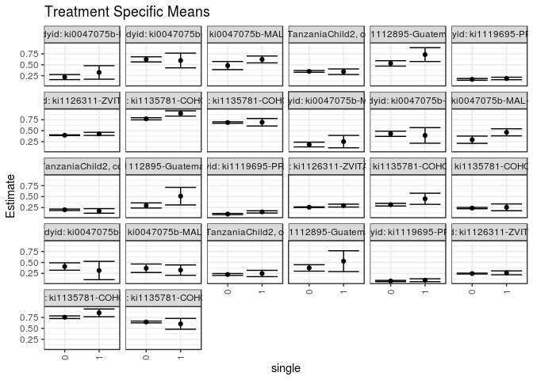

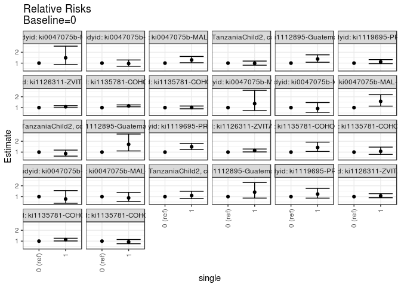

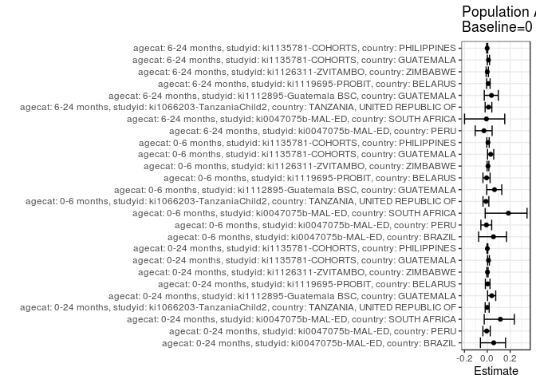

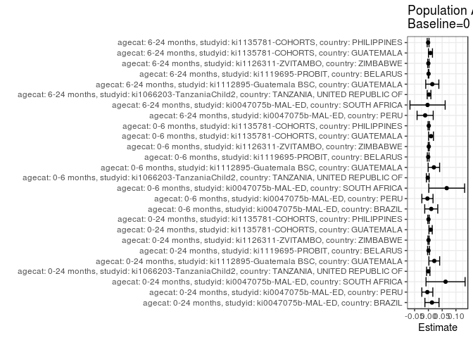

## Results Table

### Parameter: TSM

| agecat | studyid | country | intervention_level | baseline_level | estimate | ci_lower | ci_upper |
| --- | --- | --- | --- | --- | --- | --- | --- |
| 0-24 months | ki0047075b-MAL-ED | BRAZIL | 0 | NA | 0.2187520 | 0.1610110 | 0.2764930 |
| 0-24 months | ki0047075b-MAL-ED | BRAZIL | 1 | NA | 0.3249553 | 0.1705711 | 0.4793395 |
| 0-24 months | ki0047075b-MAL-ED | PERU | 0 | NA | 0.6242685 | 0.5661243 | 0.6824128 |
| 0-24 months | ki0047075b-MAL-ED | PERU | 1 | NA | 0.5989468 | 0.4307393 | 0.7671544 |
| 0-24 months | ki0047075b-MAL-ED | SOUTH AFRICA | 0 | NA | 0.4822300 | 0.3897526 | 0.5747073 |
| 0-24 months | ki0047075b-MAL-ED | SOUTH AFRICA | 1 | NA | 0.6222083 | 0.5438273 | 0.7005894 |
| 0-24 months | ki1066203-TanzaniaChild2 | TANZANIA, UNITED REPUBLIC OF | 0 | NA | 0.3486936 | 0.3285780 | 0.3688093 |
| 0-24 months | ki1066203-TanzaniaChild2 | TANZANIA, UNITED REPUBLIC OF | 1 | NA | 0.3414049 | 0.2780081 | 0.4048016 |
| 0-24 months | ki1112895-Guatemala BSC | GUATEMALA | 0 | NA | 0.5317460 | 0.4700280 | 0.5934641 |
| 0-24 months | ki1112895-Guatemala BSC | GUATEMALA | 1 | NA | 0.7333333 | 0.5748097 | 0.8918569 |
| 0-24 months | ki1119695-PROBIT | BELARUS | 0 | NA | 0.1669245 | 0.1470633 | 0.1867857 |
| 0-24 months | ki1119695-PROBIT | BELARUS | 1 | NA | 0.1869845 | 0.1587470 | 0.2152219 |
| 0-24 months | ki1126311-ZVITAMBO | ZIMBABWE | 0 | NA | 0.3962042 | 0.3878209 | 0.4045875 |
| 0-24 months | ki1126311-ZVITAMBO | ZIMBABWE | 1 | NA | 0.4269600 | 0.3919358 | 0.4619842 |
| 0-24 months | ki1135781-COHORTS | GUATEMALA | 0 | NA | 0.7715354 | 0.7468034 | 0.7962675 |
| 0-24 months | ki1135781-COHORTS | GUATEMALA | 1 | NA | 0.8939953 | 0.8338483 | 0.9541424 |
| 0-24 months | ki1135781-COHORTS | PHILIPPINES | 0 | NA | 0.6864372 | 0.6695635 | 0.7033109 |
| 0-24 months | ki1135781-COHORTS | PHILIPPINES | 1 | NA | 0.6931151 | 0.6072260 | 0.7790042 |
| 0-6 months | ki0047075b-MAL-ED | BRAZIL | 0 | NA | 0.1827411 | 0.1286598 | 0.2368224 |
| 0-6 months | ki0047075b-MAL-ED | BRAZIL | 1 | NA | 0.2500000 | 0.1082473 | 0.3917527 |
| 0-6 months | ki0047075b-MAL-ED | PERU | 0 | NA | 0.4291406 | 0.3697381 | 0.4885431 |
| 0-6 months | ki0047075b-MAL-ED | PERU | 1 | NA | 0.3919509 | 0.2137480 | 0.5701539 |
| 0-6 months | ki0047075b-MAL-ED | SOUTH AFRICA | 0 | NA | 0.2932972 | 0.2104037 | 0.3761908 |
| 0-6 months | ki0047075b-MAL-ED | SOUTH AFRICA | 1 | NA | 0.4626342 | 0.3818022 | 0.5434662 |
| 0-6 months | ki1066203-TanzaniaChild2 | TANZANIA, UNITED REPUBLIC OF | 0 | NA | 0.1981293 | 0.1812708 | 0.2149877 |
| 0-6 months | ki1066203-TanzaniaChild2 | TANZANIA, UNITED REPUBLIC OF | 1 | NA | 0.1714657 | 0.1192067 | 0.2237247 |
| 0-6 months | ki1112895-Guatemala BSC | GUATEMALA | 0 | NA | 0.2970198 | 0.2385764 | 0.3554631 |
| 0-6 months | ki1112895-Guatemala BSC | GUATEMALA | 1 | NA | 0.5100032 | 0.3086480 | 0.7113584 |
| 0-6 months | ki1119695-PROBIT | BELARUS | 0 | NA | 0.1001716 | 0.0864163 | 0.1139269 |
| 0-6 months | ki1119695-PROBIT | BELARUS | 1 | NA | 0.1492554 | 0.1239595 | 0.1745512 |
| 0-6 months | ki1126311-ZVITAMBO | ZIMBABWE | 0 | NA | 0.2566217 | 0.2491189 | 0.2641245 |
| 0-6 months | ki1126311-ZVITAMBO | ZIMBABWE | 1 | NA | 0.2935804 | 0.2604478 | 0.3267131 |
| 0-6 months | ki1135781-COHORTS | GUATEMALA | 0 | NA | 0.3148555 | 0.2845589 | 0.3451522 |
| 0-6 months | ki1135781-COHORTS | GUATEMALA | 1 | NA | 0.4496298 | 0.3225136 | 0.5767461 |
| 0-6 months | ki1135781-COHORTS | PHILIPPINES | 0 | NA | 0.2371436 | 0.2216790 | 0.2526082 |
| 0-6 months | ki1135781-COHORTS | PHILIPPINES | 1 | NA | 0.2545531 | 0.1773619 | 0.3317444 |
| 6-24 months | ki0047075b-MAL-ED | PERU | 0 | NA | 0.4076923 | 0.3229347 | 0.4924499 |
| 6-24 months | ki0047075b-MAL-ED | PERU | 1 | NA | 0.3157895 | 0.1060755 | 0.5255034 |
| 6-24 months | ki0047075b-MAL-ED | SOUTH AFRICA | 0 | NA | 0.3677297 | 0.2708213 | 0.4646381 |
| 6-24 months | ki0047075b-MAL-ED | SOUTH AFRICA | 1 | NA | 0.3248117 | 0.2062916 | 0.4433318 |
| 6-24 months | ki1066203-TanzaniaChild2 | TANZANIA, UNITED REPUBLIC OF | 0 | NA | 0.2254031 | 0.2038185 | 0.2469877 |
| 6-24 months | ki1066203-TanzaniaChild2 | TANZANIA, UNITED REPUBLIC OF | 1 | NA | 0.2480849 | 0.1758912 | 0.3202786 |
| 6-24 months | ki1112895-Guatemala BSC | GUATEMALA | 0 | NA | 0.3750000 | 0.3015949 | 0.4484051 |
| 6-24 months | ki1112895-Guatemala BSC | GUATEMALA | 1 | NA | 0.5294118 | 0.2914989 | 0.7673246 |
| 6-24 months | ki1119695-PROBIT | BELARUS | 0 | NA | 0.0761549 | 0.0620303 | 0.0902795 |
| 6-24 months | ki1119695-PROBIT | BELARUS | 1 | NA | 0.0937847 | 0.0612287 | 0.1263408 |
| 6-24 months | ki1126311-ZVITAMBO | ZIMBABWE | 0 | NA | 0.2459950 | 0.2362021 | 0.2557879 |
| 6-24 months | ki1126311-ZVITAMBO | ZIMBABWE | 1 | NA | 0.2626046 | 0.2180671 | 0.3071422 |
| 6-24 months | ki1135781-COHORTS | GUATEMALA | 0 | NA | 0.7546174 | 0.7239651 | 0.7852698 |
| 6-24 months | ki1135781-COHORTS | GUATEMALA | 1 | NA | 0.8548387 | 0.7671013 | 0.9425761 |
| 6-24 months | ki1135781-COHORTS | PHILIPPINES | 0 | NA | 0.6461740 | 0.6253914 | 0.6669566 |
| 6-24 months | ki1135781-COHORTS | PHILIPPINES | 1 | NA | 0.6034796 | 0.4800252 | 0.7269341 |

### Parameter: E(Y)

| agecat | studyid | country | intervention_level | baseline_level | estimate | ci_lower | ci_upper |
| --- | --- | --- | --- | --- | --- | --- | --- |
| 0-24 months | ki0047075b-MAL-ED | BRAZIL | NA | NA | 0.2317597 | 0.1774632 | 0.2860561 |
| 0-24 months | ki0047075b-MAL-ED | PERU | NA | NA | 0.6204620 | 0.5657315 | 0.6751926 |
| 0-24 months | ki0047075b-MAL-ED | SOUTH AFRICA | NA | NA | 0.5445860 | 0.4894148 | 0.5997572 |
| 0-24 months | ki1066203-TanzaniaChild2 | TANZANIA, UNITED REPUBLIC OF | NA | NA | 0.3482105 | 0.3290467 | 0.3673744 |
| 0-24 months | ki1112895-Guatemala BSC | GUATEMALA | NA | NA | 0.5531915 | 0.4950624 | 0.6113206 |
| 0-24 months | ki1119695-PROBIT | BELARUS | NA | NA | 0.1674854 | 0.1488048 | 0.1861659 |
| 0-24 months | ki1126311-ZVITAMBO | ZIMBABWE | NA | NA | 0.3967178 | 0.3886181 | 0.4048175 |
| 0-24 months | ki1135781-COHORTS | GUATEMALA | NA | NA | 0.7796189 | 0.7562250 | 0.8030128 |
| 0-24 months | ki1135781-COHORTS | PHILIPPINES | NA | NA | 0.6868787 | 0.6703303 | 0.7034272 |
| 0-6 months | ki0047075b-MAL-ED | BRAZIL | NA | NA | 0.1931330 | 0.1423366 | 0.2439295 |
| 0-6 months | ki0047075b-MAL-ED | PERU | NA | NA | 0.4257426 | 0.3699763 | 0.4815088 |
| 0-6 months | ki0047075b-MAL-ED | SOUTH AFRICA | NA | NA | 0.3598726 | 0.3067005 | 0.4130447 |
| 0-6 months | ki1066203-TanzaniaChild2 | TANZANIA, UNITED REPUBLIC OF | NA | NA | 0.1957895 | 0.1798275 | 0.2117515 |
| 0-6 months | ki1112895-Guatemala BSC | GUATEMALA | NA | NA | 0.3169811 | 0.2608532 | 0.3731091 |
| 0-6 months | ki1119695-PROBIT | BELARUS | NA | NA | 0.0995087 | 0.0864641 | 0.1125533 |
| 0-6 months | ki1126311-ZVITAMBO | ZIMBABWE | NA | NA | 0.2581291 | 0.2508782 | 0.2653799 |
| 0-6 months | ki1135781-COHORTS | GUATEMALA | NA | NA | 0.3244353 | 0.2950189 | 0.3538517 |
| 0-6 months | ki1135781-COHORTS | PHILIPPINES | NA | NA | 0.2385686 | 0.2233602 | 0.2537770 |
| 6-24 months | ki0047075b-MAL-ED | PERU | NA | NA | 0.3959732 | 0.3171819 | 0.4747644 |
| 6-24 months | ki0047075b-MAL-ED | SOUTH AFRICA | NA | NA | 0.3647799 | 0.2897219 | 0.4398379 |
| 6-24 months | ki1066203-TanzaniaChild2 | TANZANIA, UNITED REPUBLIC OF | NA | NA | 0.2278162 | 0.2071874 | 0.2484451 |
| 6-24 months | ki1112895-Guatemala BSC | GUATEMALA | NA | NA | 0.3891892 | 0.3187405 | 0.4596379 |
| 6-24 months | ki1119695-PROBIT | BELARUS | NA | NA | 0.0768510 | 0.0628857 | 0.0908164 |
| 6-24 months | ki1126311-ZVITAMBO | ZIMBABWE | NA | NA | 0.2458975 | 0.2364144 | 0.2553806 |
| 6-24 months | ki1135781-COHORTS | GUATEMALA | NA | NA | 0.7621951 | 0.7330377 | 0.7913526 |
| 6-24 months | ki1135781-COHORTS | PHILIPPINES | NA | NA | 0.6452074 | 0.6247246 | 0.6656902 |

### Parameter: RR

| agecat | studyid | country | intervention_level | baseline_level | estimate | ci_lower | ci_upper |
| --- | --- | --- | --- | --- | --- | --- | --- |
| 0-24 months | ki0047075b-MAL-ED | BRAZIL | 0 | 0 | 1.0000000 | 1.0000000 | 1.000000 |
| 0-24 months | ki0047075b-MAL-ED | BRAZIL | 1 | 0 | 1.4854966 | 0.8612026 | 2.562347 |
| 0-24 months | ki0047075b-MAL-ED | PERU | 0 | 0 | 1.0000000 | 1.0000000 | 1.000000 |
| 0-24 months | ki0047075b-MAL-ED | PERU | 1 | 0 | 0.9594378 | 0.7138097 | 1.289589 |
| 0-24 months | ki0047075b-MAL-ED | SOUTH AFRICA | 0 | 0 | 1.0000000 | 1.0000000 | 1.000000 |
| 0-24 months | ki0047075b-MAL-ED | SOUTH AFRICA | 1 | 0 | 1.2902731 | 1.0309456 | 1.614833 |
| 0-24 months | ki1066203-TanzaniaChild2 | TANZANIA, UNITED REPUBLIC OF | 0 | 0 | 1.0000000 | 1.0000000 | 1.000000 |
| 0-24 months | ki1066203-TanzaniaChild2 | TANZANIA, UNITED REPUBLIC OF | 1 | 0 | 0.9790969 | 0.8065517 | 1.188555 |
| 0-24 months | ki1112895-Guatemala BSC | GUATEMALA | 0 | 0 | 1.0000000 | 1.0000000 | 1.000000 |
| 0-24 months | ki1112895-Guatemala BSC | GUATEMALA | 1 | 0 | 1.3791045 | 1.0790454 | 1.762603 |
| 0-24 months | ki1119695-PROBIT | BELARUS | 0 | 0 | 1.0000000 | 1.0000000 | 1.000000 |
| 0-24 months | ki1119695-PROBIT | BELARUS | 1 | 0 | 1.1201739 | 0.9489085 | 1.322350 |
| 0-24 months | ki1126311-ZVITAMBO | ZIMBABWE | 0 | 0 | 1.0000000 | 1.0000000 | 1.000000 |
| 0-24 months | ki1126311-ZVITAMBO | ZIMBABWE | 1 | 0 | 1.0776262 | 0.9903558 | 1.172587 |
| 0-24 months | ki1135781-COHORTS | GUATEMALA | 0 | 0 | 1.0000000 | 1.0000000 | 1.000000 |
| 0-24 months | ki1135781-COHORTS | GUATEMALA | 1 | 0 | 1.1587224 | 1.0757287 | 1.248119 |
| 0-24 months | ki1135781-COHORTS | PHILIPPINES | 0 | 0 | 1.0000000 | 1.0000000 | 1.000000 |
| 0-24 months | ki1135781-COHORTS | PHILIPPINES | 1 | 0 | 1.0097284 | 0.8900857 | 1.145453 |
| 0-6 months | ki0047075b-MAL-ED | BRAZIL | 0 | 0 | 1.0000000 | 1.0000000 | 1.000000 |
| 0-6 months | ki0047075b-MAL-ED | BRAZIL | 1 | 0 | 1.3680556 | 0.7216559 | 2.593447 |
| 0-6 months | ki0047075b-MAL-ED | PERU | 0 | 0 | 1.0000000 | 1.0000000 | 1.000000 |
| 0-6 months | ki0047075b-MAL-ED | PERU | 1 | 0 | 0.9133392 | 0.5678248 | 1.469095 |
| 0-6 months | ki0047075b-MAL-ED | SOUTH AFRICA | 0 | 0 | 1.0000000 | 1.0000000 | 1.000000 |
| 0-6 months | ki0047075b-MAL-ED | SOUTH AFRICA | 1 | 0 | 1.5773561 | 1.1354495 | 2.191249 |
| 0-6 months | ki1066203-TanzaniaChild2 | TANZANIA, UNITED REPUBLIC OF | 0 | 0 | 1.0000000 | 1.0000000 | 1.000000 |
| 0-6 months | ki1066203-TanzaniaChild2 | TANZANIA, UNITED REPUBLIC OF | 1 | 0 | 0.8654235 | 0.6310127 | 1.186914 |
| 0-6 months | ki1112895-Guatemala BSC | GUATEMALA | 0 | 0 | 1.0000000 | 1.0000000 | 1.000000 |
| 0-6 months | ki1112895-Guatemala BSC | GUATEMALA | 1 | 0 | 1.7170683 | 1.1070149 | 2.663310 |
| 0-6 months | ki1119695-PROBIT | BELARUS | 0 | 0 | 1.0000000 | 1.0000000 | 1.000000 |
| 0-6 months | ki1119695-PROBIT | BELARUS | 1 | 0 | 1.4899971 | 1.2270231 | 1.809331 |
| 0-6 months | ki1126311-ZVITAMBO | ZIMBABWE | 0 | 0 | 1.0000000 | 1.0000000 | 1.000000 |
| 0-6 months | ki1126311-ZVITAMBO | ZIMBABWE | 1 | 0 | 1.1440202 | 1.0183343 | 1.285219 |
| 0-6 months | ki1135781-COHORTS | GUATEMALA | 0 | 0 | 1.0000000 | 1.0000000 | 1.000000 |
| 0-6 months | ki1135781-COHORTS | GUATEMALA | 1 | 0 | 1.4280513 | 1.0611380 | 1.921833 |
| 0-6 months | ki1135781-COHORTS | PHILIPPINES | 0 | 0 | 1.0000000 | 1.0000000 | 1.000000 |
| 0-6 months | ki1135781-COHORTS | PHILIPPINES | 1 | 0 | 1.0734134 | 0.7879646 | 1.462269 |
| 6-24 months | ki0047075b-MAL-ED | PERU | 0 | 0 | 1.0000000 | 1.0000000 | 1.000000 |
| 6-24 months | ki0047075b-MAL-ED | PERU | 1 | 0 | 0.7745780 | 0.3862340 | 1.553387 |
| 6-24 months | ki0047075b-MAL-ED | SOUTH AFRICA | 0 | 0 | 1.0000000 | 1.0000000 | 1.000000 |
| 6-24 months | ki0047075b-MAL-ED | SOUTH AFRICA | 1 | 0 | 0.8832892 | 0.5598475 | 1.393593 |
| 6-24 months | ki1066203-TanzaniaChild2 | TANZANIA, UNITED REPUBLIC OF | 0 | 0 | 1.0000000 | 1.0000000 | 1.000000 |
| 6-24 months | ki1066203-TanzaniaChild2 | TANZANIA, UNITED REPUBLIC OF | 1 | 0 | 1.1006278 | 0.8106993 | 1.494243 |
| 6-24 months | ki1112895-Guatemala BSC | GUATEMALA | 0 | 0 | 1.0000000 | 1.0000000 | 1.000000 |
| 6-24 months | ki1112895-Guatemala BSC | GUATEMALA | 1 | 0 | 1.4117647 | 0.8647352 | 2.304844 |
| 6-24 months | ki1119695-PROBIT | BELARUS | 0 | 0 | 1.0000000 | 1.0000000 | 1.000000 |
| 6-24 months | ki1119695-PROBIT | BELARUS | 1 | 0 | 1.2315005 | 0.8604988 | 1.762458 |
| 6-24 months | ki1126311-ZVITAMBO | ZIMBABWE | 0 | 0 | 1.0000000 | 1.0000000 | 1.000000 |
| 6-24 months | ki1126311-ZVITAMBO | ZIMBABWE | 1 | 0 | 1.0675203 | 0.8969769 | 1.270489 |
| 6-24 months | ki1135781-COHORTS | GUATEMALA | 0 | 0 | 1.0000000 | 1.0000000 | 1.000000 |
| 6-24 months | ki1135781-COHORTS | GUATEMALA | 1 | 0 | 1.1328107 | 1.0144231 | 1.265015 |
| 6-24 months | ki1135781-COHORTS | PHILIPPINES | 0 | 0 | 1.0000000 | 1.0000000 | 1.000000 |
| 6-24 months | ki1135781-COHORTS | PHILIPPINES | 1 | 0 | 0.9339274 | 0.7593008 | 1.148715 |

### Parameter: PAR

| agecat | studyid | country | intervention_level | baseline_level | estimate | ci_lower | ci_upper |
| --- | --- | --- | --- | --- | --- | --- | --- |
| 0-24 months | ki0047075b-MAL-ED | BRAZIL | 0 | NA | 0.0130077 | -0.0125627 | 0.0385780 |
| 0-24 months | ki0047075b-MAL-ED | PERU | 0 | NA | -0.0038065 | -0.0237229 | 0.0161099 |
| 0-24 months | ki0047075b-MAL-ED | SOUTH AFRICA | 0 | NA | 0.0623560 | -0.0085401 | 0.1332522 |
| 0-24 months | ki1066203-TanzaniaChild2 | TANZANIA, UNITED REPUBLIC OF | 0 | NA | -0.0004831 | -0.0065196 | 0.0055534 |
| 0-24 months | ki1112895-Guatemala BSC | GUATEMALA | 0 | NA | 0.0214455 | 0.0019436 | 0.0409473 |
| 0-24 months | ki1119695-PROBIT | BELARUS | 0 | NA | 0.0005608 | -0.0028154 | 0.0039371 |
| 0-24 months | ki1126311-ZVITAMBO | ZIMBABWE | 0 | NA | 0.0005136 | -0.0016560 | 0.0026832 |
| 0-24 months | ki1135781-COHORTS | GUATEMALA | 0 | NA | 0.0080835 | 0.0022198 | 0.0139471 |
| 0-24 months | ki1135781-COHORTS | PHILIPPINES | 0 | NA | 0.0004415 | -0.0021121 | 0.0029951 |
| 0-6 months | ki0047075b-MAL-ED | BRAZIL | 0 | NA | 0.0103919 | -0.0132574 | 0.0340413 |
| 0-6 months | ki0047075b-MAL-ED | PERU | 0 | NA | -0.0033980 | -0.0236078 | 0.0168118 |
| 0-6 months | ki0047075b-MAL-ED | SOUTH AFRICA | 0 | NA | 0.0665754 | 0.0016014 | 0.1315494 |
| 0-6 months | ki1066203-TanzaniaChild2 | TANZANIA, UNITED REPUBLIC OF | 0 | NA | -0.0023398 | -0.0073505 | 0.0026709 |
| 0-6 months | ki1112895-Guatemala BSC | GUATEMALA | 0 | NA | 0.0199614 | -0.0008883 | 0.0408111 |
| 0-6 months | ki1119695-PROBIT | BELARUS | 0 | NA | -0.0006629 | -0.0037677 | 0.0024419 |
| 0-6 months | ki1126311-ZVITAMBO | ZIMBABWE | 0 | NA | 0.0015073 | -0.0005087 | 0.0035234 |
| 0-6 months | ki1135781-COHORTS | GUATEMALA | 0 | NA | 0.0095798 | 0.0008432 | 0.0183163 |
| 0-6 months | ki1135781-COHORTS | PHILIPPINES | 0 | NA | 0.0014250 | -0.0010893 | 0.0039393 |
| 6-24 months | ki0047075b-MAL-ED | PERU | 0 | NA | -0.0117192 | -0.0409824 | 0.0175441 |
| 6-24 months | ki0047075b-MAL-ED | SOUTH AFRICA | 0 | NA | -0.0029499 | -0.0668078 | 0.0609081 |
| 6-24 months | ki1066203-TanzaniaChild2 | TANZANIA, UNITED REPUBLIC OF | 0 | NA | 0.0024132 | -0.0042670 | 0.0090934 |
| 6-24 months | ki1112895-Guatemala BSC | GUATEMALA | 0 | NA | 0.0141892 | -0.0095805 | 0.0379589 |
| 6-24 months | ki1119695-PROBIT | BELARUS | 0 | NA | 0.0006962 | -0.0004520 | 0.0018444 |
| 6-24 months | ki1126311-ZVITAMBO | ZIMBABWE | 0 | NA | -0.0000975 | -0.0025748 | 0.0023799 |
| 6-24 months | ki1135781-COHORTS | GUATEMALA | 0 | NA | 0.0075777 | 0.0003202 | 0.0148352 |
| 6-24 months | ki1135781-COHORTS | PHILIPPINES | 0 | NA | -0.0009666 | -0.0042844 | 0.0023512 |

### Parameter: PAF

| agecat | studyid | country | intervention_level | baseline_level | estimate | ci_lower | ci_upper |
| --- | --- | --- | --- | --- | --- | --- | --- |
| 0-24 months | ki0047075b-MAL-ED | BRAZIL | 0 | NA | 0.0561257 | -0.0603665 | 0.1598200 |
| 0-24 months | ki0047075b-MAL-ED | PERU | 0 | NA | -0.0061349 | -0.0387594 | 0.0254648 |
| 0-24 months | ki0047075b-MAL-ED | SOUTH AFRICA | 0 | NA | 0.1145017 | -0.0271590 | 0.2366253 |
| 0-24 months | ki1066203-TanzaniaChild2 | TANZANIA, UNITED REPUBLIC OF | 0 | NA | -0.0013874 | -0.0188741 | 0.0157991 |
| 0-24 months | ki1112895-Guatemala BSC | GUATEMALA | 0 | NA | 0.0387668 | 0.0025234 | 0.0736932 |
| 0-24 months | ki1119695-PROBIT | BELARUS | 0 | NA | 0.0033486 | -0.0171214 | 0.0234065 |
| 0-24 months | ki1126311-ZVITAMBO | ZIMBABWE | 0 | NA | 0.0012946 | -0.0041893 | 0.0067486 |
| 0-24 months | ki1135781-COHORTS | GUATEMALA | 0 | NA | 0.0103685 | 0.0027780 | 0.0179012 |
| 0-24 months | ki1135781-COHORTS | PHILIPPINES | 0 | NA | 0.0006428 | -0.0030826 | 0.0043544 |
| 0-6 months | ki0047075b-MAL-ED | BRAZIL | 0 | NA | 0.0538071 | -0.0764105 | 0.1682718 |
| 0-6 months | ki0047075b-MAL-ED | PERU | 0 | NA | -0.0079814 | -0.0565935 | 0.0383941 |
| 0-6 months | ki0047075b-MAL-ED | SOUTH AFRICA | 0 | NA | 0.1849970 | -0.0188114 | 0.3480345 |
| 0-6 months | ki1066203-TanzaniaChild2 | TANZANIA, UNITED REPUBLIC OF | 0 | NA | -0.0119506 | -0.0378615 | 0.0133135 |
| 0-6 months | ki1112895-Guatemala BSC | GUATEMALA | 0 | NA | 0.0629734 | -0.0053138 | 0.1266221 |
| 0-6 months | ki1119695-PROBIT | BELARUS | 0 | NA | -0.0066619 | -0.0382595 | 0.0239740 |
| 0-6 months | ki1126311-ZVITAMBO | ZIMBABWE | 0 | NA | 0.0058394 | -0.0020014 | 0.0136189 |
| 0-6 months | ki1135781-COHORTS | GUATEMALA | 0 | NA | 0.0295276 | 0.0022125 | 0.0560949 |
| 0-6 months | ki1135781-COHORTS | PHILIPPINES | 0 | NA | 0.0059730 | -0.0046368 | 0.0164708 |
| 6-24 months | ki0047075b-MAL-ED | PERU | 0 | NA | -0.0295958 | -0.1063031 | 0.0417928 |
| 6-24 months | ki0047075b-MAL-ED | SOUTH AFRICA | 0 | NA | -0.0080867 | -0.1993402 | 0.1526685 |
| 6-24 months | ki1066203-TanzaniaChild2 | TANZANIA, UNITED REPUBLIC OF | 0 | NA | 0.0105925 | -0.0191699 | 0.0394858 |
| 6-24 months | ki1112895-Guatemala BSC | GUATEMALA | 0 | NA | 0.0364583 | -0.0266802 | 0.0957140 |
| 6-24 months | ki1119695-PROBIT | BELARUS | 0 | NA | 0.0090590 | -0.0062488 | 0.0241339 |
| 6-24 months | ki1126311-ZVITAMBO | ZIMBABWE | 0 | NA | -0.0003964 | -0.0105222 | 0.0096279 |
| 6-24 months | ki1135781-COHORTS | GUATEMALA | 0 | NA | 0.0099420 | 0.0003332 | 0.0194583 |
| 6-24 months | ki1135781-COHORTS | PHILIPPINES | 0 | NA | -0.0014981 | -0.0066533 | 0.0036307 |